# Central African Republic Exports Time Series Analysis (Final Project STA137)

Lidia Wolday, Sara Sofia Abril Guevara, Wengel Semma

2024-03-16

# 1 Introduction

In this project, we analyze, model and forecast the Central African Republic Exports activity time series data. Central African Republic (CAR) is a landlocked country that is located in the Sub-Saharan region of Africa and gained independence from France on August 13, 1960, becoming a sovereign nation. Besides, the country has had 2 civil wars: the Central African Republic Bush War (2004-2007) and the Central African Republic Civil War in 2013 when despite of efforts to broker peace agreements and stabilize the situation, violence and insecurity persist in various parts of the country nowadays. According to the [International Monetary Fund](https://www.imf.org/en/News/Articles/2023/04/28/pr23129-IMF-Executive-Board-Approves-ECF-Arrangement-Central-African-Republic) (multilateral economic institution primarily associated with the global north) the CAR economy heavily relies on agriculture but also on its exports of good and services including diamonds, wood, coffee, and cotton.

Since exports are one of the backbones of the economy in this country, it is essential to model their behavior and predict what the future of this trade will look like. We are provided by a dataset from [World Bank](https://data.worldbank.org/indicator/NE.EXP.GNFS.ZS?end=2017&locations=CF&start=1960) that contains information since CAR became an independent republic Therefore, it has 58 observations of records from 1960-2017 with 9 variables: country, code, GDP, year, growth, CPI, imports, exports, and population. In this case, we only focus on the variable of exports, which represents the proportion of a country’s Gross Domestic Product (GDP) accounted for by exports. This is often expressed as a percentage to provide a standardized measure of a country’s trade activity relative to the size of its economy, and we are going to analyze it to make predictions for the following years based on past behaviors. It is important to note that due to the political instability of the country and the pandemic that occurred three years after the last data analyzed, these predictions may not necessarily reflect reality. This is not due to the lack of power of the method, but rather due to unexpected or unpredictable circumstances.

# 2 Initial Data Analysis

In order to find a model, the first step that we follow is to plot our data of exports and see the patterns it exhibits.

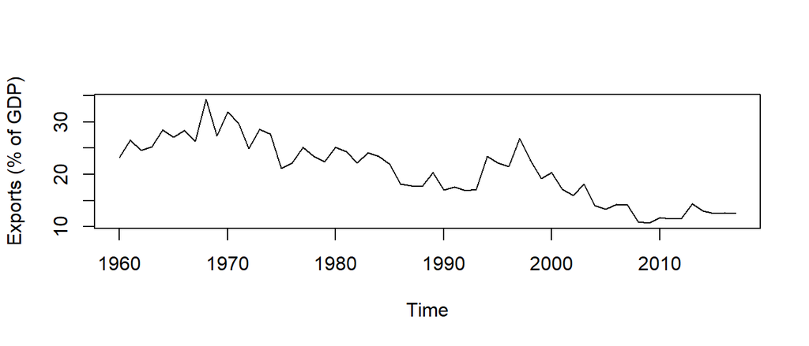

Central African Republic Exports (% of the GDP)

## 2.1 Regarding to the data

The data indicates that the political situation in the Central African Republic has significantly affected its economy, especially in the last 25 years. Interestingly, the two civil wars had different impacts.

During the first civil war (2004), while the GDP continued to rise (See Figure 4 in Appendix of Plots), there was a noticeable decline in the percentage of exports relative to GDP (Figure 1). This suggests that political instability may have led to conflicts with trading partners, negatively affecting commerce. Despite the overall GDP growth, the participation of the exports in that GDP did not growth that much.

In contrast, the second civil war (2013) saw a decrease in GDP alongside an increase in the percentage of exports relative to GDP. This implies that internal economic issues were more severe than those affecting international trade. Despite domestic challenges, there was a greater reliance on exports to sustain economic activity.

## 2.2 Regarding to the model

There are assumptions of time series analysis that we want our model to accomplish such as stationarity, normality, constant variance, and independent and identically distributed errors. If our data exhibits a trend, we need to detrend it before modeling to make it stationary.

**Stationarity:** a stationary time series has a constant mean, variance and auto correlation over time. This allows for more reliable forecast, and consistent pattern over time;making it easier to develop robust forecasting. Some visual ways to determine this are no trends, or seasonality. In order to analyze the stationarity we plot the data and use the as adf test to see whether our data is stationary or not.

From the Figure 1, we can see that our data has trend, making it non-stationary. To further prove that, we can perform **Augmented Dickey-Fuller test** (full result in Table 4 in appendix) at significance $\alpha=0.1$ to check stationarity in order to have a stable forecasting:

- Null Hypothesis ($H_0$): The time series has a unit root and is non-stationary.
- Alternative Hypothesis ($H_1$): The time series does not have a unit root and is stationary.

The decision rule states that if $\text{p-value}\geq\alpha$, we fail reject $H_0$. If `p-value`$<\alpha$, we reject the $H_0$.

Since the p-value is 0.10055$\approx\alpha=0.01$, we fail to reject the $H_0$ and conclude that **our data is not stationary**. After this, we will try methods of transformation.

# 3 Transformation

Given the conclusion above, we tried the three different transformation methods which are used to remove trends, and stabilize the variance.

**Differencing $x_t-x_{t-1}$:**

When we took the difference of our data, we saw that there was a reduction in trend (see Figure 2).In addition, we found a $\text{p-value}=0.08< \alpha=0.1$ (Table 1), meaning our differenced data is stationary.

**Log Transformation $log(x_t)$:**

**Difference of log $log(x_t)-log(x_{t-1})$:**

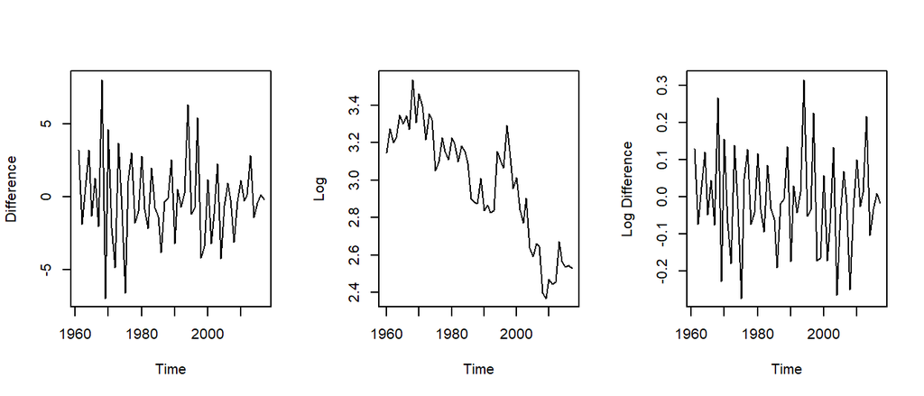

Time series plot of transformed variables

p-values for ADF Test applied to transformations

| Difference | Log | Log difference |
| --- | --- | --- |
| 0.088 | 0.182 | 0.086 |

Given the values of its significance with respect to $\alpha=0.1$, we drop the option of $\log$ transformations and will use the differenced and difference log transformed data to do model fitting.

# 4 Model Fitting, Selection and Diagnostics

After comparing several models, we have summarized our results in Table 2, which presents the values of AIC, AICc, and BIC, along with the summary of Ljung-Box statistics assessing the independence of errors. These statistics are derived from a test evaluating the independence of errors, which represent white noise in this context. The hypothesis statements for this test are as follows: $H_0:$ The errors ($w_t$) are independent VS $H_1:$ The errors ($w_t$) are not independent.

We observed that only the ARIMA(2,0,2) model, both for difference and log difference, yielded $\text{p-values}> 0.1=\alpha$. Consequently, we discarded the other eight models as they failed to satisfy the condition of independence of white noise.

Finally, we used the AIC/BIc criteria to pick our best model since both models have similar diagnostics. Since the **log difference ARIMA(2,0,2)** has the lowest AIC/BIC, we have concluded that it is **the best model to do forecasting**.

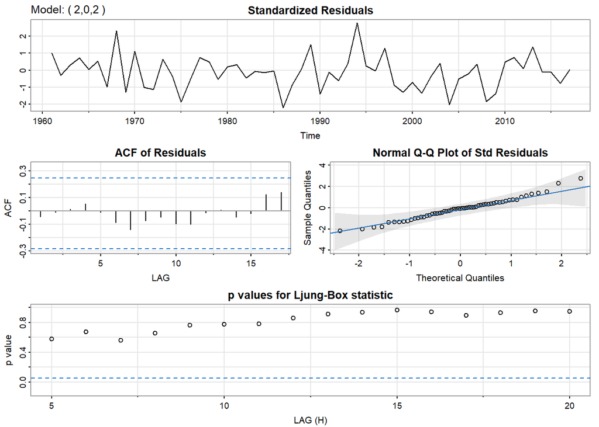

Comparison of wt p-vals AIC and BIC for model candidates

[output not shown]

# 5 Best model

According to the model selection, we extract the coefficients and see that all of them are significant, therefore all of them are included in the model.

Coefficients and significance of ARIMA(2,0,2) model for CAR exports

|  | Estimate | SE | t.value | p.value |
| --- | --- | --- | --- | --- |
| ar1 | -0.6924 | 0.1455 | -4.7577 | 0.0000 |
| ar2 | -0.8006 | 0.1879 | -4.2612 | 0.0001 |
| ma1 | 0.3985 | 0.2067 | 1.9278 | 0.0592 |
| ma2 | 0.5571 | 0.2985 | 1.8663 | 0.0675 |

## 5.1 Model of the transformed variable

$$y_{t}=\log(x_t)-\log(x_{t-1}) \qquad
\Rightarrow \qquad y_t=\log\frac{x_t}{x_{t-1}}$$

# 6 Prediction

The predictions indicate a stabilization in export values, as evidenced by the mean values hovering around zero. A predicted value of 0 for $\log\frac{x_t}{x_{t-1}}$ implies no expected change in exports compared to the previous period, suggesting stability in export trends.

However, the wide prediction intervals suggest considerable uncertainty in the forecasts. This uncertainty stems from the high variability in the data, which has experienced significant fluctuations in both positive and negative directions, making it challenging to predict a clear trend.

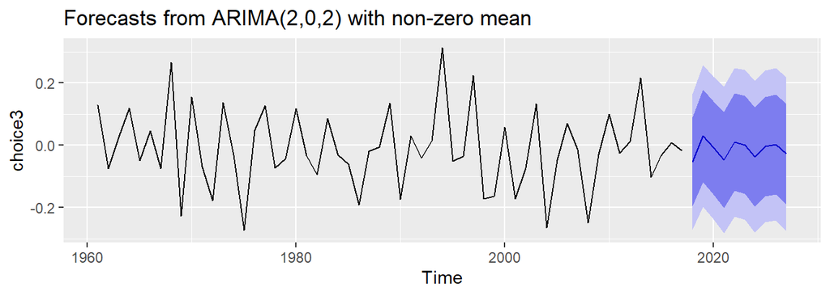

Forecast

```
## Time Series:
## Start = 2018
## End = 2025
## Frequency = 1
## [1] 0.9476854 1.0306966 0.9922319 0.9538703 1.0098296 1.0012448 0.9632234
## [8] 0.9959708
```

Finally, looking at the values published by the World Bank for CAR [here](https://data.worldbank.org/indicator/NE.EXP.GNFS.ZS?end=2022&locations=CF&start=1960) from 2018 - 2022, they are inside our 95% prediction interval.

# 7 Conclusion

Regarding the prediction we saw in general a expected change of 0, which implies a suggestion of stabilization that coincides with the values of the years that had happened. However, the prediction intervals cover an area that might suggest big changes towards increasing or decreasing, which could be showing a limitation of the model due to variables related to the instability of the country in the past that affect the exports value but are difficult to predict. Therefore, it’s apparent that the model may not fully capture the underlying dynamics of the time series. Several factors could contribute to this limitation, including the model’s simplicity, insufficient consideration of all relevant influencing factors, or the inherent difficulty or unpredictability of certain factors (such as civil wars) that significantly affect the data.

# 8 References

- IMF Executive Board Approves a US$191.4 million Extended Credit Facility Arrangement with the Central African Republic. International Monetary Fund. (April 27, 2023). [IMFLink](https://www.imf.org/en/News/Articles/2023/04/28/pr23129-IMF-Executive-Board-Approves-ECF-Arrangement-Central-African-Republic)
- World Bank. (n.d.). Exports of Goods and Services (% of GDP). Retrieved from [WBLink](https://data.worldbank.org/indicator/NE.EXP.GNFS.ZS?end=2017&locations=CF&start=1960) (Dataset provided by instructor)

# 9 Disclaimer

- The references to multilateral institutions like IMF or WB are merely with academic purposes of obtaining information and do not reflect the political views or validations of the authors.

# 10 Apendix

## 10.1 Plots and Tables Appendix

Here we present some addional tables and plots that were referenced in the report but were not printed for the sake of the length and cohesion of the document.

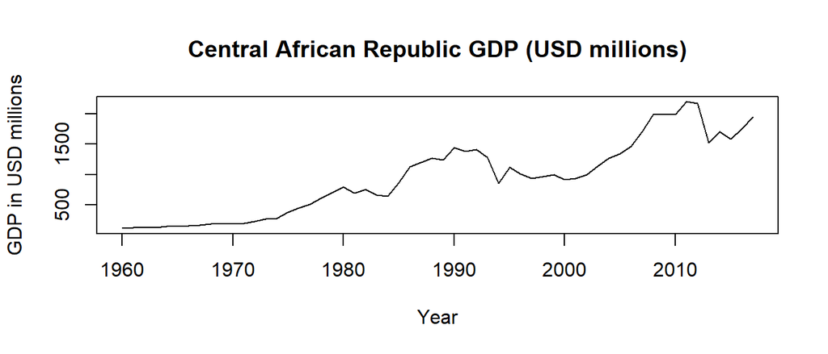

Central African Republic GDP (USD millions) **Not required but related to exports

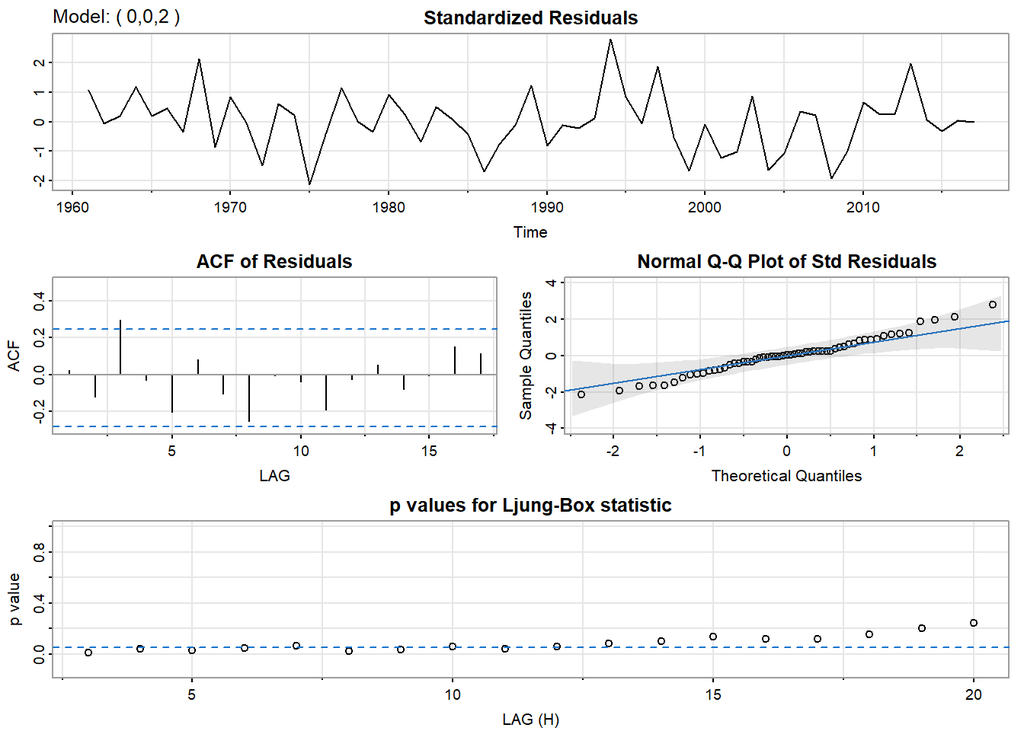

ARIMA(0,0,2) model for log difference

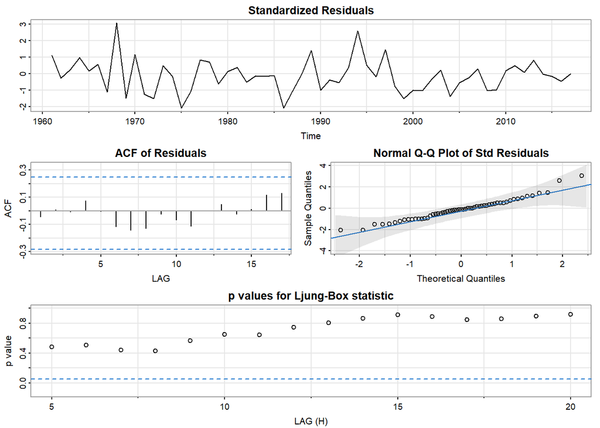

ARIMA((2,0,2) for diff

Augmented Dickey-Fuller Test for original data

|  | unlist(adf.test(mydata)) |
| --- | --- |
| statistic.Dickey-Fuller | -3.17442916391773 |
| parameter.Lag order | 3 |
| alternative | stationary |
| p.value | 0.100553425951662 |
| method | Augmented Dickey-Fuller Test |
| data.name | mydata |

## 10.2 Code Appendix

```r
knitr::opts_chunk$set(echo = FALSE)
library(astsa)
library(tseries)
library(forecast)
library(knitr)

load("finalproject.Rdata")
mydata<-ts(finalPro_data$Exports, start = 1960, end = 2017)
#par(mfrow=c(1,2))
#ts.plot(ts(finalPro_data$GDP/1000000, start = 1960, end = 2017),main = "Central African Republic GDP (USD millions)", xlab = "Year", ylab = "GDP in USD millions")
#ts.plot(ts(finalPro_data$GDP/finalPro_data$Population, start = 1960, end = 2017), main = "Central African Republic GDP per capita", xlab = "Year", ylab = "GDP per capita")
ts.plot(mydata, xlab = "Time", ylab = "Exports (% of GDP)")
adftestres = adf.test(mydata)
pvaladftest = adftestres$p.value
acf(mydata)
pacf(mydata)
choice1<-diff(mydata)
par(mfrow = c(2, 2))
ts.plot(choice1)
acf(choice1)
pacf(choice1)
adfdiff<-adf.test(choice1)
par(mfrow = c(2, 2))
choice2=log(mydata)
ts.plot(choice2)
acf(choice2)
pacf(choice2)
adfchoice2<-adf.test(choice2)
par(mfrow = c(2, 2))
choice3=diff(choice2)
ts.plot(choice3)
acf(choice3)
pacf(choice3)
adfchoice3<-adf.test(choice3)

par(mfrow = c(1, 3))
ts.plot(choice1, gpars=list(ylab="Difference"))
ts.plot(choice2, gpars=list(ylab="Log"))
ts.plot(choice3, gpars=list(ylab="Log Difference"))
kable(rbind(c("Difference", "Log", "Log difference"),c(round(adfdiff$p.value,3), round(adfchoice2$p.value,3), round(adfchoice3$p.value,3))),caption = "p-values for ADF Test applied to transformations")
ar1_d = sarima(choice1, 0,0,1)
ar2_d = sarima(choice1,0,0,2)
ar1_ld = sarima(choice3,0,0,1 )
ar2_ld = sarima(choice3,0,0,2 )
ari1_d = sarima(choice1, 0, 1, 1, no.constant=TRUE)

arima111_d = sarima(choice1, 1, 1, 1, no.constant=TRUE)
arma12_d = sarima(choice1, 1, 0, 2, no.constant=TRUE)
arima112_d = sarima(choice1, 1, 1, 2, no.constant=TRUE)
arma22_d = suppressMessages(sarima(choice1, 2, 0, 2, no.constant=TRUE, details = TRUE, Model = FALSE))

arma22_ld = suppressMessages(sarima(choice3, 2, 0, 2, no.constant=TRUE, details = TRUE))
  str(arma22_ld)
models <- data.frame(
  Model = c("ARIMA(1,0,0) with differenced",
            "ARIMA(2,0,0) with differenced",
            "ARIMA(1,0,0) with log difference",
            "ARIMA(2,0,0) with log difference",
            "ARIMA(1,1,0) with differenced",
            "ARIMA(1,1,1) with differenced",
            "ARIMA(1,0,2) with differenced",
            "ARIMA(1,1,2) with differenced",
            "ARIMA(2,0,2) with differenced",
            "ARIMA(2,0,2) with log difference"),
  Errors_wt_independent = c(FALSE, FALSE, FALSE, FALSE, FALSE, FALSE, FALSE, FALSE, TRUE, TRUE)
)


kable(cbind(models,round(rbind(ar1_d$ICs, ar2_d$ICs, ar1_ld$ICs, ar2_ld$ICs, ari1_d$ICs, arima111_d$ICs, arma12_d$ICs, arima112_d$ICs, arma22_d$ICs, arma22_ld$ICs),3)),caption = "Comparison of wt p-vals AIC and BIC for model candidates")
kable(arma22_ld$ttable, caption = "Coefficients and significance of ARIMA(2,0,2) model for CAR exports")
finalmodel=arima(choice3,order=c(2,0,2))

#exp(finalmodel$coef)
forecstx = forecast(finalmodel,h=8)
autoplot(forecast(finalmodel))

#str(forecstx)
unlist(exp(forecstx$mean))
par(mfrow=c(1,1))
ts.plot(ts(finalPro_data$GDP/1000000, start = 1960, end = 2017),main = "Central African Republic GDP (USD millions)", xlab = "Year", ylab = "GDP in USD millions")

ar2_ld = sarima(choice3,0,0,2 )
arma22_d = suppressMessages(sarima(choice1, 2, 0, 2, no.constant=TRUE, details = TRUE, Model = FALSE))

kable(as.data.frame(unlist(adf.test(mydata))), caption = "Augmented Dickey-Fuller Test for original data")
```